# Partie I - (Données du système Ford GoBike:201902-fordgobike-tripdata)

## par (MBOCK MBOCK Georges Christian)

[figure not shown]

## Table de Matières

- Introduction
- Importation des packages et du jeu de données
- Évaluation des données
- Nettoyage des données
- Structure du jeu de Données
- Analyse Univariée
- Analyse Bivariée
- Analyse Multivariée
- Analyse des utilisateurs n'ayant pas précisé leur sexe
- Conclusions
- Limitations
- Bibliographie

## Introduction

### Description du jeu de données

Les données qui feront l'objet de notre étude sont celles du Sytème Ford GoBike [Cliquez-ici](https://github.com/BetaNYC/Bike-Share-Data-Best-Practices/wiki/Bike-Share-Data-Systems.). Cet ensemble de données comprend des informations sur les trajets individuels effectués dans un système de partage de vélos couvrant la grande région de la baie de San Francisco.

Ainsi, ces informations sont organisées dans seize(16) colonnes entre autres:

'duration_sec': durée du trajet (en seconde)

'start_time', ('end_time'): date du début, (de fin) du trajet (AA-MM-JJ h:m:s.t)

'start_station_id', ('end_station_id'): numero d'identification du lieu du commencement, (de fin) du trajet

'start_station_name', ('end_station_name'): nom du lieu de commencement, (de fin)du trajet

'start_station_latitude','start_station_longitude', 'end_station_latitude', 'end_station_longitude': coordonnées des lieux de commencement et fin du trajet

'bike_id': immatriculation du vélo

'user_type': type d'utilisateur(Abonné ou Client)

'member_birth_year', ('member_gender'): année de naissance de l'utilisateur, (sexe de l'utilisateur)

'bike_share_for_all_trip': type de vélo(Vélo tout terrain ou non)

> **Rubric Tip**: Document your approach and findings in markdown cells. Use comments and docstrings in code cells to document the code functionality.

> **Rubric Tip**: Markup cells should have headers and text that organize your thoughts, findings, and what you plan on investigating next.

## Importation des packages et du jeu de données

```python
# importation des packages néccessaires
import numpy as np
import pandas as pd
import matplotlib.pyplot as plt
import seaborn as sb

# importer le package plotly pour la visualisation
import plotly.express as px

%matplotlib inline
```

```python
# Importation du jeu de données
df = pd.read_csv('201902-fordgobike-tripdata.csv')
df.head(5)
```

|  | duration_sec | start_time | end_time | start_station_id | start_station_name | start_station_latitude | start_station_longitude | end_station_id | end_station_name | end_station_latitude | end_station_longitude | bike_id | user_type | member_birth_year | member_gender | bike_share_for_all_trip |
| --- | --- | --- | --- | --- | --- | --- | --- | --- | --- | --- | --- | --- | --- | --- | --- | --- |
| 0 | 52185 | 2019-02-28 17:32:10.1450 | 2019-03-01 08:01:55.9750 | 21.0 | Montgomery St BART Station (Market St at 2nd St) | 37.789625 | -122.400811 | 13.0 | Commercial St at Montgomery St | 37.794231 | -122.402923 | 4902 | Customer | 1984.0 | Male | No |
| 1 | 42521 | 2019-02-28 18:53:21.7890 | 2019-03-01 06:42:03.0560 | 23.0 | The Embarcadero at Steuart St | 37.791464 | -122.391034 | 81.0 | Berry St at 4th St | 37.775880 | -122.393170 | 2535 | Customer | NaN | NaN | No |
| 2 | 61854 | 2019-02-28 12:13:13.2180 | 2019-03-01 05:24:08.1460 | 86.0 | Market St at Dolores St | 37.769305 | -122.426826 | 3.0 | Powell St BART Station (Market St at 4th St) | 37.786375 | -122.404904 | 5905 | Customer | 1972.0 | Male | No |
| 3 | 36490 | 2019-02-28 17:54:26.0100 | 2019-03-01 04:02:36.8420 | 375.0 | Grove St at Masonic Ave | 37.774836 | -122.446546 | 70.0 | Central Ave at Fell St | 37.773311 | -122.444293 | 6638 | Subscriber | 1989.0 | Other | No |
| 4 | 1585 | 2019-02-28 23:54:18.5490 | 2019-03-01 00:20:44.0740 | 7.0 | Frank H Ogawa Plaza | 37.804562 | -122.271738 | 222.0 | 10th Ave at E 15th St | 37.792714 | -122.248780 | 4898 | Subscriber | 1974.0 | Male | Yes |

## Évaluation des données

```python
# Configuration de l'affichage
pd.set_option('display.max_rows', None)
```

```python
# Observation de la dimansion et les caractéristique
print(df.shape)
print(df.info())
```

```
(183412, 16)
<class 'pandas.core.frame.DataFrame'>
RangeIndex: 183412 entries, 0 to 183411
Data columns (total 16 columns):
 #   Column                   Non-Null Count   Dtype
---  ------                   --------------   -----
 0   duration_sec             183412 non-null  int64
 1   start_time               183412 non-null  object
 2   end_time                 183412 non-null  object
 3   start_station_id         183215 non-null  float64
 4   start_station_name       183215 non-null  object
 5   start_station_latitude   183412 non-null  float64
 6   start_station_longitude  183412 non-null  float64
 7   end_station_id           183215 non-null  float64
 8   end_station_name         183215 non-null  object
 9   end_station_latitude     183412 non-null  float64
 10  end_station_longitude    183412 non-null  float64
 11  bike_id                  183412 non-null  int64
 12  user_type                183412 non-null  object
 13  member_birth_year        175147 non-null  float64
 14  member_gender            175147 non-null  object
 15  bike_share_for_all_trip  183412 non-null  object
dtypes: float64(7), int64(2), object(7)
memory usage: 22.4+ MB
None
```

```python
# Observation des types de valeurs
df.dtypes
```

```
duration_sec                 int64
start_time                  object
end_time                    object
start_station_id           float64
start_station_name          object
start_station_latitude     float64
start_station_longitude    float64
end_station_id             float64
end_station_name            object
end_station_latitude       float64
end_station_longitude      float64
bike_id                      int64
user_type                   object
member_birth_year          float64
member_gender               object
bike_share_for_all_trip     object
dtype: object
```

```python
# Recherche des données dupliquées
df.duplicated().sum()
```

```
0
```

```python
# Inspection des manquantes
df.isnull().sum()
```

```
duration_sec                  0
start_time                    0
end_time                      0
start_station_id            197
start_station_name          197
start_station_latitude        0
start_station_longitude       0
end_station_id              197
end_station_name            197
end_station_latitude          0
end_station_longitude         0
bike_id                       0
user_type                     0
member_birth_year          8265
member_gender              8265
bike_share_for_all_trip       0
dtype: int64
```

```python
# Le nombre de valeurs des variables catégorielles
df.nunique()
```

```
duration_sec                 4752
start_time                 183401
end_time                   183397
start_station_id              329
start_station_name            329
start_station_latitude        334
start_station_longitude       335
end_station_id                329
end_station_name              329
end_station_latitude          335
end_station_longitude         335
bike_id                      4646
user_type                       2
member_birth_year              75
member_gender                   3
bike_share_for_all_trip         2
dtype: int64
```

## Problèmes

**I. Problèmes de structures**

1. Les variables: "start_time", "end_time", "start_station_name", "end_station_name" ont des observations qui forment plusieurs lignes par cellules.

**II. Problèmes de qualité**

1. La variable "member_birth_year" est formatée en float
2. Les variables: "start_station_id", "start_station_name", "end_station_id", "end_station_name", "member_birth_year" et "member_gender" ont des données manquantes

## Nettoyage des données

Dans cette section, nous nettoyerons **tous les problèmes que nous avons documenté pendant l'évaluation**.

**Copie des données originales**

```python
# Copie des données en vue de les nettoyager
df_clean = df.copy()
```

### I- **Problème de structure**

### Problème #:

"start_time", "end_time", "start_station_name", "end_station_name" ont des observations qui forment plusieurs lignes par cellules.

#### Définition

- Cas des variables "start_time" et "end_time"
  - Eclater les variables "start_time" en "jour"
  - Créer une variable "start_period" indiquant l'heure à laquelle les trajets ont débutés
  - Creér la variable "week" éventuellement intéressante avec pour valeurs week1, week2, ... qui indiquera si le a commencé à la première semaine du mois ou deuxieme semaine ...
  - Supprimer la variable "end_time" car elle ne nous interessa pas trop
- Cas des variables "start_station_name", "end_station_name"
  - Supprimer les variables "start_station_name" et "end_station_name"

#### Code

```python
# Dimension est mise en varible pour pouvoir utiliser soit le nombre de ligne ou nombre de colonne à l'aide des indices
dim = df_clean.shape
```

```python
# Creation de la variable "start_period"
df_clean['start_period'] = "heure"
```

```python
# Des sous string à retenir pour reformater les valeur de 'start_time' en jour et en heure
print(df_clean['start_time'].iloc[0][11:13])
print(df_clean['start_time'].iloc[0][0:10])
```

```
17
2019-02-28
```

```python
# Rechargement des sous-strings dans les listes pour utiliser dans la suite
start_time_reformed =[]
periode = []
for i in range (0, dim[0], 1):
    start_time_reformed.append(df_clean['start_time'].iloc[i][0:10])
    periode.append(df_clean['start_time'].iloc[i][11:13])
```

```python
# Reformatage de la variable 'start_time'
# Le compteur count nous permet de voir l'éxécution s'est arrétée
count = 0

for i in range (0, dim[0], 1):
    df_clean['start_period'][i] = periode[i]
    df_clean['start_time'][i] = start_time_reformed[i]

    count +=1
print(count)
```

```
183412
```

```python
# Suite du reformatage
day_renamed={"2019-02-11":"2019/02/11", "2019-02-12":"2019/02/12", "2019-02-06":"2019/02/06","2019-02-05":"2019/02/05",
            "2019-02-08":"2019/02/08", "2019-02-04":"2019/02/04", "2019-02-07":"2019/02/07", "2019-02-15":"2019/02/15",
             "2019-02-01":"2019/02/01", "2019-02-14":"2019/02/14", "2019-02-10":"2019/02/10", "2019-02-13":"2019/02/13",
             "2019-02-09":"2019/02/09", "2019-02-02":"2019/02/02", "2019-02-03":"2019/02/03", "2019-02-18":"2019/02/18",
             "2019-02-17":"2019/02/17", "2019-02-19":"2019/02/19", "2019-02-16":"2019/02/16", "2019-02-22":"2019/02/22",
             "2019-02-25":"2019/02/25", "2019-02-28":"2019/02/28", "2019-02-20":"2019/02/20", "2019-02-21":"2019/02/21",
             "2019-02-23":"2019/02/23", "2019-02-24":"2019/02/24", "2019-02-26":"2019/02/26", "2019-02-27":"2019/02/27"
            }
df_clean.replace(day_renamed, inplace=True)
```

```python
# Creation et correction des valeurs de la variable "start_week"
df_clean['start_Week']= 'week'
for i in range(0, 183412, 1):
    if df_clean['start_time'][i] in ["2019/02/01","2019/02/02","2019/02/03"]:
        df_clean['start_Week'][i]= 'week1'
    if df_clean['start_time'][i] in ["2019/02/04","2019/02/05","2019/02/06", "2019/02/07", "2019/02/08", "2019/02/09", "2019/02/10"]:
        df_clean['start_Week'][i]= 'week2'
    if df_clean['start_time'][i] in ["2019/02/11","2019/02/12","2019/02/13", "2019/02/14", "2019/02/15", "2019/02/16", "2019/02/17"]:
        df_clean['start_Week'][i]= "week3"
    if df_clean['start_time'][i] in ["2019/02/18","2019/02/19","2019/02/20", "2019/02/21", "2019/02/22", "2019/02/23", "2019/02/24"]:
        df_clean['start_Week'][i]= "week4"
    if df_clean['start_time'][i] in ["2019/02/25","2019/02/26","2019/02/27", "2019/02/28"]:
        df_clean['start_Week'][i]= "week5"
```

```python
# Suppression des variables "start_station_name" et "end_station_name"
df_clean.drop(columns=["start_station_name", "end_time", "end_station_name"], axis= 1, inplace =True)
```

#### Test

```python
df_clean.head(5)
```

|  | duration_sec | start_time | start_station_id | start_station_latitude | start_station_longitude | end_station_id | end_station_latitude | end_station_longitude | bike_id | user_type | member_birth_year | member_gender | bike_share_for_all_trip | start_period | start_Week |
| --- | --- | --- | --- | --- | --- | --- | --- | --- | --- | --- | --- | --- | --- | --- | --- |
| 0 | 52185 | 2019/02/28 | 21.0 | 37.789625 | -122.400811 | 13.0 | 37.794231 | -122.402923 | 4902 | Customer | 1984.0 | Male | No | 17 | week5 |
| 1 | 42521 | 2019/02/28 | 23.0 | 37.791464 | -122.391034 | 81.0 | 37.775880 | -122.393170 | 2535 | Customer | NaN | NaN | No | 18 | week5 |
| 2 | 61854 | 2019/02/28 | 86.0 | 37.769305 | -122.426826 | 3.0 | 37.786375 | -122.404904 | 5905 | Customer | 1972.0 | Male | No | 12 | week5 |
| 3 | 36490 | 2019/02/28 | 375.0 | 37.774836 | -122.446546 | 70.0 | 37.773311 | -122.444293 | 6638 | Subscriber | 1989.0 | Other | No | 17 | week5 |
| 4 | 1585 | 2019/02/28 | 7.0 | 37.804562 | -122.271738 | 222.0 | 37.792714 | -122.248780 | 4898 | Subscriber | 1974.0 | Male | Yes | 23 | week5 |

### II- **Problème de qualité**

### Problème #1:

Les variables "member_birth_year" "start_station_id", "end_station_id" sont formatés en float. Et la variable "bike_id" en int.

#### Définition

- Transformer les variables "member_birth_year" "start_station_id", "end_station_id", "bike_id" en variable catégorielle.

#### Code

```python
# Transformation des variables "member_birth_year", "start_station_id",
# "end_station_id" et "bike_id" en variables catégorielles.
df_clean["member_birth_year"] = df_clean["member_birth_year"].astype("category")
df_clean["start_station_id"] = df_clean["start_station_id"].astype("category")
df_clean["end_station_id"] = df_clean["end_station_id"].astype("category")
df_clean["bike_id"] = df_clean["bike_id"].astype("category")
```

#### Test

```python
print(df_clean["member_birth_year"].dtypes)
print(df_clean["start_station_id"].dtypes)
print(df_clean["end_station_id"].dtypes)
print(df_clean["bike_id"].dtypes)
```

```
category
category
category
category
```

### Problème #2:

Les variables: "start_station_id", "end_station_id", "member_birth_year" et "member_gender" ont des données manquantes

```python
df_clean.isna().sum()
```

```
duration_sec                  0
start_time                    0
start_station_id            197
start_station_latitude        0
start_station_longitude       0
end_station_id              197
end_station_latitude          0
end_station_longitude         0
bike_id                       0
user_type                     0
member_birth_year          8265
member_gender              8265
bike_share_for_all_trip       0
start_period                  0
start_Week                    0
dtype: int64
```

#### Code

```python
# Suppression des 197 lignes ayant les valeurs manquantes
# pour des variables "start_station_id", "start_station_name"
# "end_station_id" et "end_station_name"

df_clean = df_clean[df_clean["start_station_id"].isna() == False]
```

```python
# Séparation des 8265 lignes ayant les données manquantes
# pour des variables "member_birth_year" et "member_gender"
# de jeu données pour en faire
# un sous jeu de données nommé sous_data dans le but de les analyser
data = df_clean
sous_data = data[data["member_birth_year"].isna() == True]
df_clean = df_clean[df_clean["member_birth_year"].isna() == False]
```

```python
# Suppression des colonnes "member_birth_year" et "member_gender"
# dans le sus jeu de données

sous_data.drop(["member_birth_year", "member_gender"], axis=1, inplace = True)
```

#### Test

```python
df_clean.info()
```

```
<class 'pandas.core.frame.DataFrame'>
Int64Index: 174952 entries, 0 to 183411
Data columns (total 15 columns):
 #   Column                   Non-Null Count   Dtype
---  ------                   --------------   -----
 0   duration_sec             174952 non-null  int64
 1   start_time               174952 non-null  object
 2   start_station_id         174952 non-null  category
 3   start_station_latitude   174952 non-null  float64
 4   start_station_longitude  174952 non-null  float64
 5   end_station_id           174952 non-null  category
 6   end_station_latitude     174952 non-null  float64
 7   end_station_longitude    174952 non-null  float64
 8   bike_id                  174952 non-null  category
 9   user_type                174952 non-null  object
 10  member_birth_year        174952 non-null  category
 11  member_gender            174952 non-null  object
 12  bike_share_for_all_trip  174952 non-null  object
 13  start_period             174952 non-null  object
 14  start_Week               174952 non-null  object
dtypes: category(4), float64(4), int64(1), object(6)
memory usage: 17.4+ MB
```

```python
sous_data.info()
```

```
<class 'pandas.core.frame.DataFrame'>
Int64Index: 8263 entries, 1 to 183402
Data columns (total 13 columns):
 #   Column                   Non-Null Count  Dtype
---  ------                   --------------  -----
 0   duration_sec             8263 non-null   int64
 1   start_time               8263 non-null   object
 2   start_station_id         8263 non-null   category
 3   start_station_latitude   8263 non-null   float64
 4   start_station_longitude  8263 non-null   float64
 5   end_station_id           8263 non-null   category
 6   end_station_latitude     8263 non-null   float64
 7   end_station_longitude    8263 non-null   float64
 8   bike_id                  8263 non-null   category
 9   user_type                8263 non-null   object
 10  bike_share_for_all_trip  8263 non-null   object
 11  start_period             8263 non-null   object
 12  start_Week               8263 non-null   object
dtypes: category(3), float64(4), int64(1), object(5)
memory usage: 945.2+ KB
```

### Structure du jeu de Données

> Parmi ces variables noous avons: **duration_sec**, **start_station_latitude**, **start_station_longitude**, **end_station_latitude**, **end_station_longitude** qui sont des variables quantitatives.

> Les variables **start_time**, **member_birth_year**, **start_Week**, **start_periode** sont des variables catégorielles ordinales

> Les variables **start_station_id**, **end_station_id**, **bike_id** sont catégorielles nominatives

### Principale(s) caractéristique(s) intéressante(s) du jeu de données

> Ce qui m'interresse est de savoir : Quelles variables qui peuvent-elles influencer le fait qu'un utilisateur soit un abonné ou un client au mois de Février ?

> Notre but final est de prédire le fait qu'un utilisateur soit un abonné ou un client. Dès lors, notre variable principale est "user_type"

### Caractéristiques du jeu de données qui aideront à mener notre enquête sur la caractéristique cible

> Les variables **duration_sec**, **member_birth_year**, **start_time**, **member_gender**, **start_Week**, **start_period** nous aideront à mener notre enquête

## Analyse Univariée

> Dans cette section, nous étudions les distributions des variables individuelles. Si nous voyons des points inhabituels ou des valeurs aberrantes, nous regarderons plus en profondeur pour nettoyer les choses.

> Nous utiliserons le cadre **"Question-Visualisation-Observations"** tout au long de l'exploration. Ce cadre impliquera de poser une question à partir des données, de créer une visualisation pour trouver des réponses, puis d'enregistrer des observations après chaque visualisation.

```python
#Changement de theme
#sb.set_theme()
```

#### Question #1

Quel était le type d'utilisateur le plus frequent au mois de Février?

```python
# Tranformation de la variable "user_type" en variable catégorielle
df_clean["user_type"] = df_clean["user_type"].astype("category")
```

#### Visualisation #1

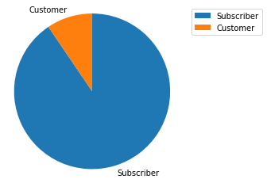

```python
# Observation des fréquences des abonnés et clients au mois de Février
sorted_counts =df_clean['user_type'].value_counts()
plt.pie(sorted_counts, labels = sorted_counts.index, startangle = 90, counterclock = False);
plt.legend(bbox_to_anchor=(1.05, 1.0), loc='upper left');
plt.axis('square');
```

#### Observation #1

D'après notre schema, nous constactons qu'il la grande majorité étaient des d'abonnés au mois de Février

#### Question #2

Quelle est l'année de naissance qui a éffectué plus de parcours au mois de Février?

```python
df_clean['member_birth_year'].describe()
```

```
count     174952.0
unique        75.0
top         1988.0
freq       10214.0
Name: member_birth_year, dtype: float64
```

#### Visualisation #2

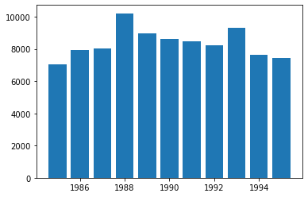

```python
# Obsevation de l'année de naissance des utilisateurs ayant le plus éffectué des trajets
y = df_clean['member_birth_year'].value_counts()[df_clean['member_birth_year'].value_counts().values > 7000];
x = df_clean['member_birth_year'].value_counts()[df_clean['member_birth_year'].value_counts().values > 7000].index;
plt.bar(x, y);
```

#### Observation #2

On constate d'après le graphique les utilisateurs ayant effectué la plupart des trajets sont nées en 1988

#### Question #3

Quel jour du mois sont efféctués la plupart des trajets?

#### Visualisation #3

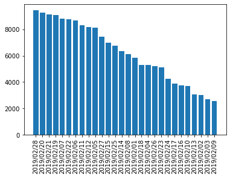

```python
# Observation du jour ayant eu le plus de trajet
x = df_clean['start_time'].value_counts(sort=True).index
y = df_clean['start_time'].value_counts(sort=True)
plt.xticks(rotation=90)
plt.bar(x, y);
```

#### Observation #3

Nous constactons que les trajets ont été effectués le 28 Février 2019

#### Question # 4

A quelle moment de la journée sont souvent éffectués la plupart des trajet?